# Desafio Estágio em Dados - Itaú

### Bibliotecas utilizadas:

- matplotlib: visualização de dados e criação de gráficos
- pandas: manipulação, limpeza e análise de dados
- seaborn: serve para criação de gráficos mais belos e robustos
- statsmodels: criação dos testes de hipótese

```python
import matplotlib.pyplot as graphic
import pandas as pd
from statsmodels.stats.weightstats import ztest
import seaborn
import warnings

# desliga mensagens FutureWarning
warnings.simplefilter(action='ignore', category=FutureWarning)

# carrega os dados do arquivo CSV
dados = pd.read_csv('Ecommerce_DBS.csv')
display(dados.sample(5))
```

|  | Customer ID | Purchase Date | Product Category | Product Price | Quantity | Total Purchase Amount | NPS | Customer Age | Gender | Source | Country | State | Latitude | Longituide |
| --- | --- | --- | --- | --- | --- | --- | --- | --- | --- | --- | --- | --- | --- | --- |
| 152890 | 6688 | 11/03/2023 | Electronics | 219 | 5 | 2449 | 4 | 39 | Female | Organic Search | United States | Alabama | 32.806671 | -86.791130 |
| 228100 | 9959 | 15/03/2022 | Books | 206 | 3 | 2229 | 10 | 54 | Female | SEM | United States | New York | 42.165726 | -74.948051 |
| 223646 | 9770 | 02/03/2020 | Home | 160 | 5 | 3035 | 4 | 47 | Female | Organic Search | United States | Kansas | 32.806671 | -86.791130 |
| 188938 | 20748 | 22/05/2023 | Books | 323 | 1 | 3316 | 9 | 56 | Female | SEM | United States | Louisiana | 31.169546 | -91.867805 |
| 183085 | 21228 | 22/01/2021 | Books | 72 | 5 | 829 | 3 | 55 | Female | FaceBook campaign | United States | California | 36.116203 | -119.681564 |

## Higienização e Normalização da base

```python
# exibe o nome das colunas para verificar se tem caracter especial ou espaço
dados.columns
```

```
Index(['Customer ID', 'Purchase Date', 'Product Category', 'Product Price',
       'Quantity', 'Total Purchase Amount', 'NPS', 'Customer Age ', 'Gender',
       'Source', 'Country', 'State', 'Latitude', 'Longituide'],
      dtype='object')
```

```python
# removendo as colunas não utilizadas
dados = dados.drop(columns=['Total Purchase Amount',
                          'Country',
                          'State',
                          'Latitude',
                          'Longituide'])

#definindo nomes das colunas como constantes
CLIENTE_ID = 'cliente_id'
DATA_COMPRA = 'data_compra'
CATEGORIA_PRODUTO = 'categoria_produto'
PRECO = 'preco'
QUANTIDADE = 'quantidade'
NPS = 'nps'
IDADE = 'idade'
GENERO = 'genero'
CANAL = 'canal'
ANO_COMPRA = 'ano_compra'
FAIXA_ETARIA = 'faixa_etaria'

# renomeando o nome das colunas que serão utilizadas
dados = dados.rename(columns={'Customer ID': CLIENTE_ID,
                              'Purchase Date': DATA_COMPRA,
                              'Product Category': CATEGORIA_PRODUTO,
                              'Product Price': PRECO,
                              'Quantity': QUANTIDADE,
                              'NPS': NPS,
                              'Customer Age ': IDADE,
                              'Gender': GENERO,
                              'Source': CANAL})

# removendo linhas com missing values. Considerando o valor SEM da coluna canal como sendo uma loja com endereço físico.
dados = dados.dropna()
```

```python
# exibe informações sobre as colunas
dados.info()
```

```
<class 'pandas.core.frame.DataFrame'>
RangeIndex: 250000 entries, 0 to 249999
Data columns (total 9 columns):
 #   Column             Non-Null Count   Dtype
---  ------             --------------   -----
 0   cliente_id         250000 non-null  int64
 1   data_compra        250000 non-null  object
 2   categoria_produto  250000 non-null  object
 3   preco              250000 non-null  int64
 4   quantidade         250000 non-null  int64
 5   nps                250000 non-null  int64
 6   idade              250000 non-null  int64
 7   genero             250000 non-null  object
 8   canal              250000 non-null  object
dtypes: int64(5), object(4)
memory usage: 17.2+ MB
```

```python
# converte tipo de dado da coluna data_compra para date
dados.data_compra = pd.to_datetime(dados.data_compra, format='%d/%m/%Y')

# cria a coluna ano_compra para filtragem
dados[ANO_COMPRA] = dados.data_compra.dt.year

display(dados.sample(5))
```

|  | cliente_id | data_compra | categoria_produto | preco | quantidade | nps | idade | genero | canal | ano_compra |
| --- | --- | --- | --- | --- | --- | --- | --- | --- | --- | --- |
| 28858 | 15759 | 2021-09-30 | Home | 423 | 4 | 5 | 52 | Male | Instagram Campign | 2021 |
| 128745 | 5686 | 2021-01-14 | Clothing | 305 | 4 | 8 | 45 | Female | Organic Search | 2021 |
| 201099 | 15016 | 2021-10-30 | Books | 253 | 5 | 5 | 69 | Male | Organic Search | 2021 |
| 161152 | 7054 | 2020-06-20 | Books | 329 | 3 | 2 | 27 | Female | FaceBook campaign | 2020 |
| 100075 | 31918 | 2021-01-27 | Clothing | 160 | 5 | 8 | 28 | Female | Instagram Campign | 2021 |

## Analisando a base de dados, qual o tipo de público (considerando gênero e idade) e o canal ideal para vender determinado tipo de produto?

### Resposta:

- Electronics: No topo de vendas está o sexo feminino da faixa etária de 42 a 49 anos com os canais de campanhas de Instagram e Facebook.
- Home: No topo de vendas está o sexo masculino das faixas etárias de 18 a 25 e 50 a 57 anos com os canais de campanhas de Instagram.
- Books: No topo de vendas está o sexo feminino das faixas etárias de 34 a 41 e 26 a 33 anos respectivamente com os canais de campanhas de Instagram e Facebook.
- Clothing: No topo de vendas está o sexo feminino da faixa etária de 26 a 33 anos com o canal SEM

```python
# define faixas etárias
idade_limites = [18, 25, 33, 41, 49, 57, 65, 90]
textos_eixo_x = ['18-25', '26-33', '34-41', '42-49', '50-57', '58-65', '66+']
dados[FAIXA_ETARIA] = pd.cut(dados.idade, bins=idade_limites, labels=textos_eixo_x, right=False)

# elimina dados duplicados de clientes
dados_clientes = dados.drop_duplicates(subset=CLIENTE_ID)

# pega lista de produtos
produto_lista = dados_clientes.categoria_produto.unique()

# para cada produto verifica o número de clientes segmentados por gênero, canal e faixa etária
for produto in produto_lista:
    dados_produto = dados_clientes[dados_clientes.categoria_produto == produto]
    dados_agrupados = dados_produto.groupby([FAIXA_ETARIA,GENERO,CANAL]).cliente_id.count().reset_index()
    dados_ordenados_top_5 = dados_agrupados.sort_values(by=[CLIENTE_ID], ascending=False).head(5)
    print(f"\nTotal de clientes para o produto {produto} por faixa etária, gênero e canal")
    print(dados_ordenados_top_5)
```

```
Total de clientes para o produto Electronics por faixa etária, gênero e canal
   faixa_etaria  genero              canal  cliente_id
25        42-49  Female  Instagram Campign         221
24        42-49  Female  FaceBook campaign         220
17        34-41  Female  Instagram Campign         218
41        58-65  Female  Instagram Campign         215
12        26-33    Male  FaceBook campaign         215

Total de clientes para o produto Home por faixa etária, gênero e canal
   faixa_etaria  genero              canal  cliente_id
5         18-25    Male  Instagram Campign         224
37        50-57    Male  Instagram Campign         224
25        42-49  Female  Instagram Campign         220
45        58-65    Male  Instagram Campign         217
20        34-41    Male  FaceBook campaign         212

Total de clientes para o produto Books por faixa etária, gênero e canal
   faixa_etaria  genero              canal  cliente_id
17        34-41  Female  Instagram Campign         335
8         26-33  Female  FaceBook campaign         332
9         26-33  Female  Instagram Campign         328
23        34-41    Male                SEM         321
20        34-41    Male  FaceBook campaign         317

Total de clientes para o produto Clothing por faixa etária, gênero e canal
   faixa_etaria  genero              canal  cliente_id
11        26-33  Female                SEM         341
25        42-49  Female  Instagram Campign         326
37        50-57    Male  Instagram Campign         325
9         26-33  Female  Instagram Campign         318
43        58-65  Female                SEM         313
```

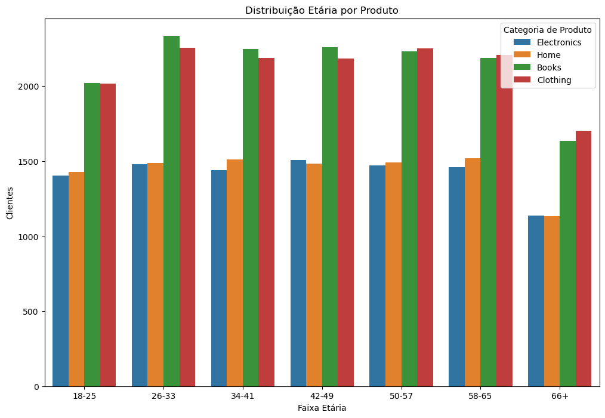

```python
# desenha gráfico de barras faixa etária x produto
graphic.figure(figsize=(12, 8))
barra = seaborn.countplot(x=FAIXA_ETARIA, hue=CATEGORIA_PRODUTO, data=dados_clientes)
barra.legend(title='Categoria de Produto')
graphic.title('Distribuição Etária por Produto')
graphic.xlabel('Faixa Etária')
graphic.ylabel('Clientes')
graphic.show()
```

### Modelo de inferência estatística e testes de hipóteses:

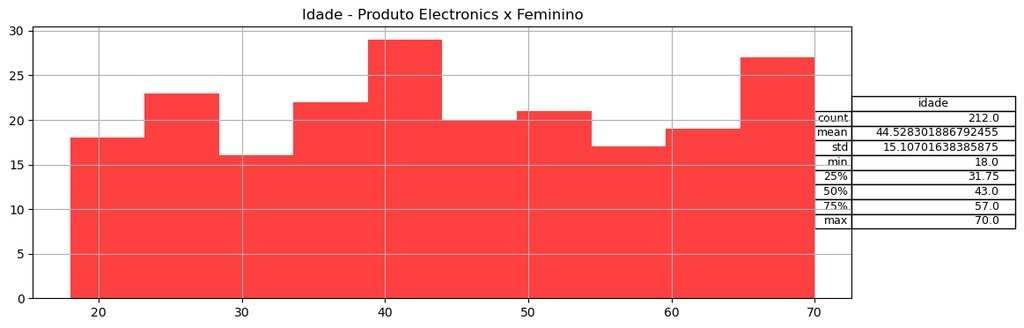

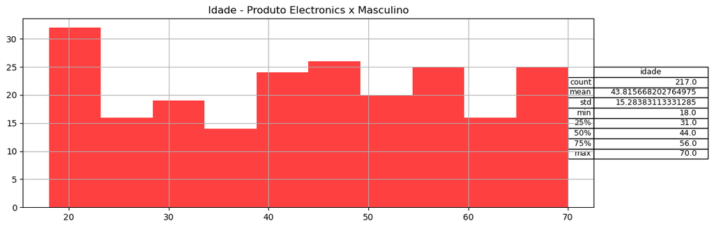

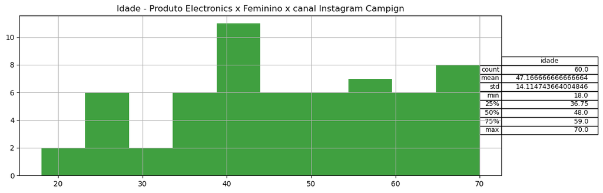

```
Existe uma diferença significativa nas idades [43, 42, 41] em termos de compra de produtos Electronics para pessoas do gênero Feminino do canal Instagram Campign.
```

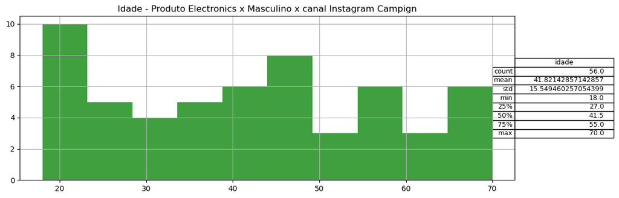

```
Não há evidências suficientes para rejeitar a hipótese nula.
Não há diferença significativa nas faixas etárias em termos de compra de produtos Electronics para pessoas do gênero Masculino do canal Instagram Campign.
```

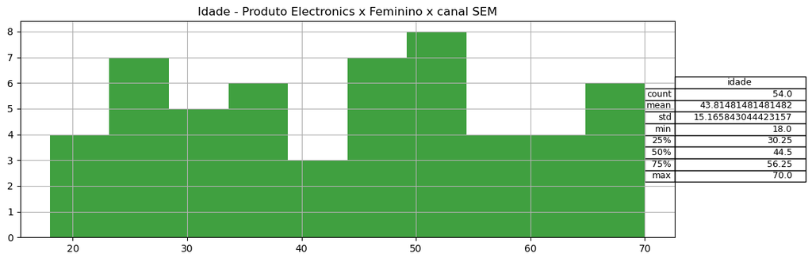

```
Existe uma diferença significativa nas idades [39, 38, 37, 36] em termos de compra de produtos Electronics para pessoas do gênero Feminino do canal SEM.
```

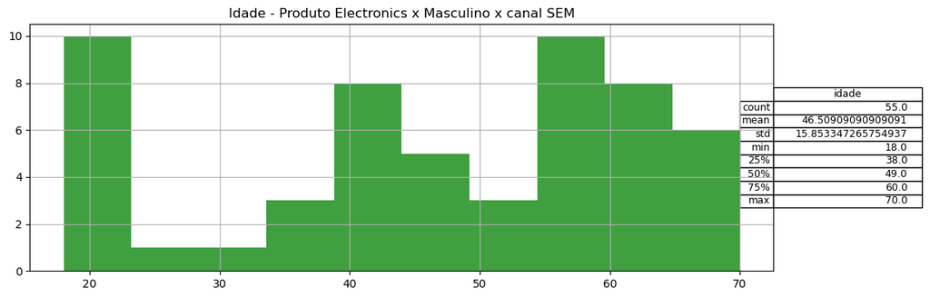

```
Existe uma diferença significativa nas idades [42, 41, 40, 39] em termos de compra de produtos Electronics para pessoas do gênero Masculino do canal SEM.
```

[figure not shown]

```
Existe uma diferença significativa nas idades [38, 37, 36, 35] em termos de compra de produtos Electronics para pessoas do gênero Feminino do canal FaceBook campaign.
```

[figure not shown]

```
Existe uma diferença significativa nas idades [40, 39, 38] em termos de compra de produtos Electronics para pessoas do gênero Masculino do canal FaceBook campaign.
```

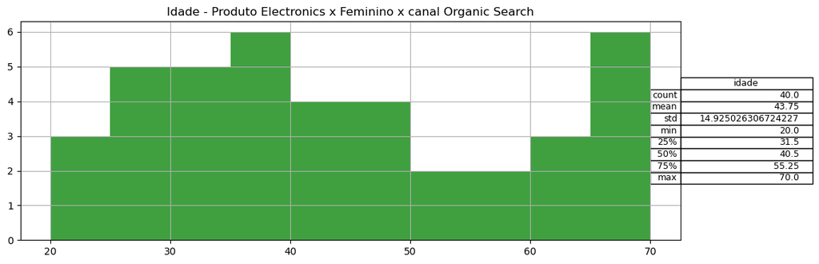

```
Existe uma diferença significativa nas idades [39, 38, 37, 36, 35] em termos de compra de produtos Electronics para pessoas do gênero Feminino do canal Organic Search.
```

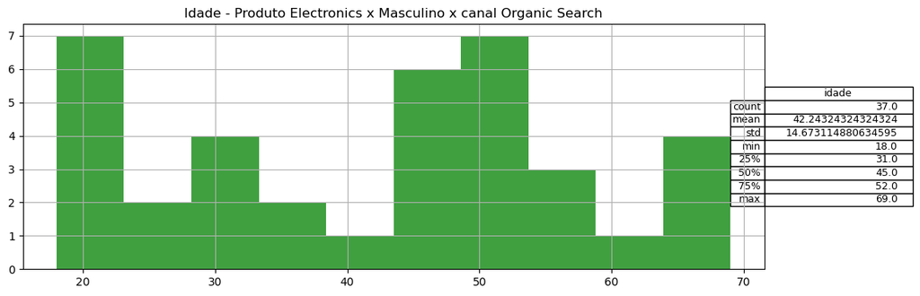

```
Não há evidências suficientes para rejeitar a hipótese nula.
Não há diferença significativa nas faixas etárias em termos de compra de produtos Electronics para pessoas do gênero Masculino do canal Organic Search.
```

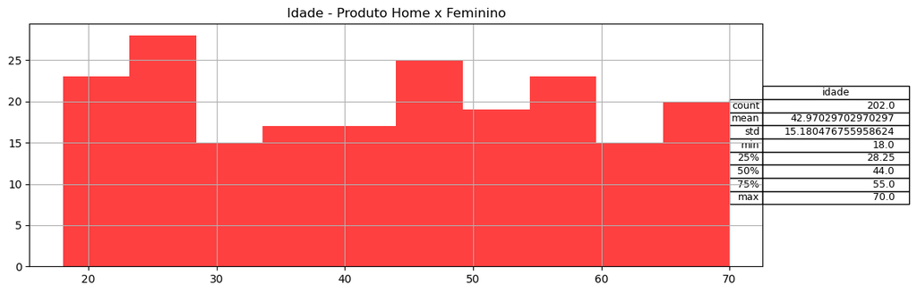

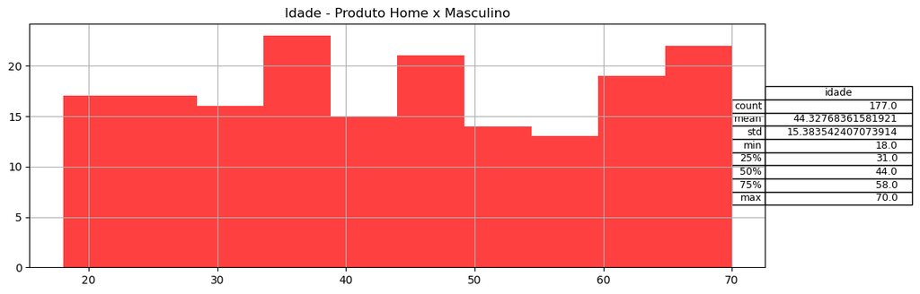

[28 more figures not shown]

```
Existe uma diferença significativa nas idades [39, 38] em termos de compra de produtos Clothing para pessoas do gênero Masculino do canal Organic Search.
```

```python
# pega linhas aleatórias gerando amostra de uma população
dados_randomicos = dados_clientes.sample(2000)

# pega lista de canais
canal_lista = dados_clientes.canal.unique()

FEMININO = 'Feminino'
MASCULINO = 'Masculino'

def criar_histograma_idade_por_produto_genero(produto, colValGenero, faceColor, genero):
    fig, axes = graphic.subplots(nrows=1, ncols=1, figsize=(12,4))
    dados_histograma = dados_randomicos.loc[(dados_randomicos.categoria_produto == produto) & (dados_randomicos.genero == colValGenero), [IDADE,CANAL]]
    axes.hist(dados_histograma.idade, density=False, facecolor=faceColor, alpha=0.75)
    axes.grid(True)
    axes.set_title(f'Idade - Produto {produto} x {genero}')
    criar_dados_estatisticos(dados_histograma, IDADE)
    return dados_histograma

def criar_histograma_idade_por_produto_genero_canal(produto, canal, faceColor, genero, dados):
    fig, axes = graphic.subplots(nrows=1, ncols=1, figsize=(12,4))
    dados_histograma =  dados[dados.canal == canal]
    axes.hist(dados_histograma.idade, density=False, facecolor=faceColor, alpha=0.75)
    axes.grid(True)
    axes.set_title(f'Idade - Produto {produto} x {genero} x canal {canal}')
    criar_dados_estatisticos(dados_histograma, IDADE)
    return dados_histograma

def criar_dados_estatisticos(dados, colName):
    resumo = pd.DataFrame(dados[colName].describe())
    graphic.table(
        cellText=resumo.values,
        colWidths = [0.2]*2,
        rowLabels=resumo.index,
        colLabels=resumo.columns,
        cellLoc = 'right', rowLoc = 'right',
        loc='right'
    )
    graphic.show()

def testar_hipotese_idade_teste_z(dados, produto, canal, genero, idadeMin, idadeMax):
    NIVEL_DE_SIGNIFICANCIA = 0.05
    start_index = idadeMax
    stop_index = idadeMin-1
    step = -1
    idades_valida = []
    hipotese_nula_aceita = True
    for idade in range(start_index, stop_index, step):
        resultado = ztest(dados[IDADE], value=idade)
        estatistica = resultado[0]
        valor_p = resultado[1]
        if estatistica > 0:
            if float(str(valor_p)[:4]) < 0.05:
                hipotese_nula_aceita = False
                idades_valida.append(idade)
    if hipotese_nula_aceita:
        print('Não há evidências suficientes para rejeitar a hipótese nula.')
        print(f'Não há diferença significativa nas faixas etárias em termos de compra de produtos {produto} para pessoas do gênero {genero} do canal {canal}.')
    else:
        print(f'Existe uma diferença significativa nas idades {idades_valida} em termos de compra de produtos {produto} para pessoas do gênero {genero} do canal {canal}.')
    print()

for produto in produto_lista:
    dados_idade_x_female = criar_histograma_idade_por_produto_genero(produto, 'Female', 'r', FEMININO)
    dados_idade_x_male = criar_histograma_idade_por_produto_genero(produto, 'Male', 'r', MASCULINO)
    for canal in canal_lista:
        dados_idade_x_female_x_canal = criar_histograma_idade_por_produto_genero_canal(produto, canal, 'g', FEMININO, dados_idade_x_female)
        testar_hipotese_idade_teste_z(dados_idade_x_female_x_canal, produto, canal, FEMININO, 18, 70)
        dados_idade_x_male_x_canal = criar_histograma_idade_por_produto_genero_canal(produto, canal, 'g', MASCULINO, dados_idade_x_male)
        testar_hipotese_idade_teste_z(dados_idade_x_male_x_canal, produto, canal, MASCULINO, 38, 42)
```

## 1 - Quais os produtos mais vendidos considerando os últimos 3 anos?

### Resposta:

- No consolidado dos últimos 3 anos, a categoria de produto mais vendida é Clothing, seguida por Books.
- Porém em 2023, Books ficou em primeiro, a frente de Clothing.

```python
# agrupa categoria de produto por ano e soma quantidade de compra
total_por_produto_x_ano = dados.groupby([CATEGORIA_PRODUTO, ANO_COMPRA]).quantidade.sum().reset_index()

# pega os últimos 3 anos
ultimos_anos = total_por_produto_x_ano.ano_compra.unique()[-3:]

# filtra linhas para os últimos 3 anos
total_por_produto_x_ano = total_por_produto_x_ano[total_por_produto_x_ano.ano_compra.isin(ultimos_anos)]

# agrupa novamente por produto e soma a quantidade de compra para os últimos 3 anos
total_consolidado_por_produto_x_ultimos_anos = total_por_produto_x_ano.groupby(CATEGORIA_PRODUTO).quantidade.sum().reset_index()

consolidado_ordenado = total_consolidado_por_produto_x_ultimos_anos.sort_values(by=[QUANTIDADE], ascending=False)
display(consolidado_ordenado)
```

|  | categoria_produto | quantidade |
| --- | --- | --- |
| 1 | Clothing | 164688 |
| 0 | Books | 163000 |
| 2 | Electronics | 109328 |
| 3 | Home | 108509 |

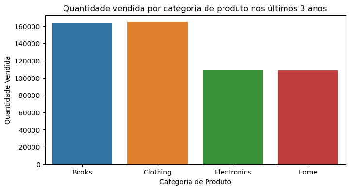

```python
# desenha gráfico de barras Categoria de Produto x Quantidade consolidado
graphic.figure(figsize=(8, 4))
seaborn.barplot(x=CATEGORIA_PRODUTO, y=QUANTIDADE, data=total_consolidado_por_produto_x_ultimos_anos)
graphic.xlabel('Categoria de Produto')
graphic.ylabel('Quantidade Vendida')
graphic.title('Quantidade vendida por categoria de produto nos últimos 3 anos')
graphic.show()
```

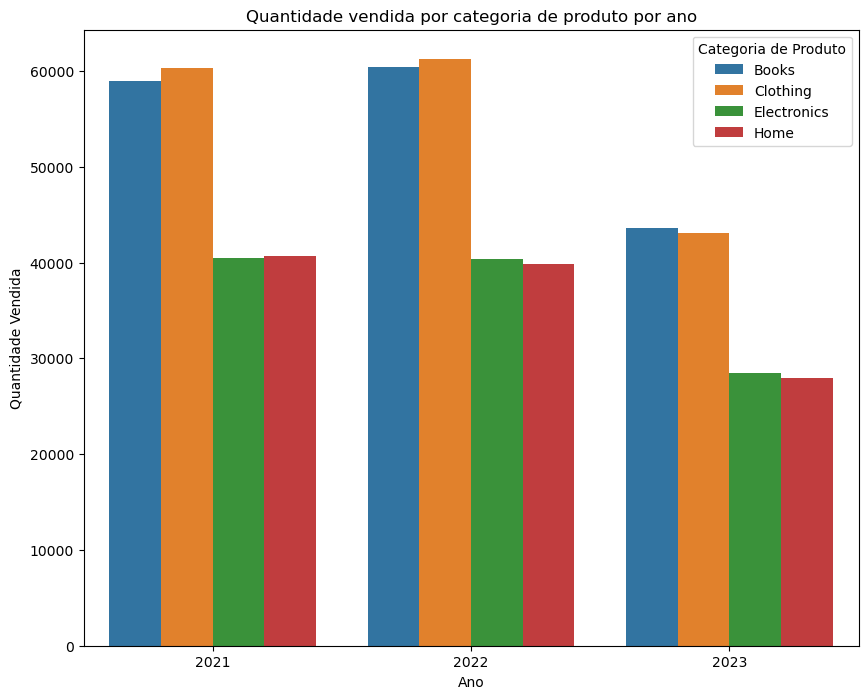

```python
# desenha gráfico de barras Categoria de Produto x Quantidade em cada um dos 3 últimos anos
graphic.figure(figsize=(10, 8))
barra = seaborn.barplot(x=ANO_COMPRA, y=QUANTIDADE, hue=CATEGORIA_PRODUTO, data=total_por_produto_x_ano)
barra.legend(title='Categoria de Produto')
graphic.xlabel('Ano')
graphic.ylabel('Quantidade Vendida')
graphic.title('Quantidade vendida por categoria de produto por ano')
graphic.show()
```

## 2 - Qual o produto mais caro e o mais barato?

### Resposta:

Se analisarmos somente pelas colunas de produto e preço iremos notar:

- o preço mais alto é 500 para as quatro categorias de produtos Books, Clothing, Electronics e Home
- o preço mais baixo é 10 para as quatro categorias de produtos Books, Clothing, Electronics e Home

```python
#verifica qual é o maior preço
maior_preco_por_produto = dados.groupby(CATEGORIA_PRODUTO).preco.max().reset_index()
print('Maior preço por produto:')
print(maior_preco_por_produto.sort_values(by=[PRECO], ascending=False))
```

```
Maior preço por produto:
  categoria_produto  preco
0             Books    500
1          Clothing    500
2       Electronics    500
3              Home    500
```

```python
# verifica qual é o menor preço
menor_preco_por_produto = dados.groupby(CATEGORIA_PRODUTO).preco.min().reset_index()
print('Menor preço por produto:')
print(menor_preco_por_produto.sort_values(by=[PRECO]))
```

```
Menor preço por produto:
  categoria_produto  preco
0             Books     10
1          Clothing     10
2       Electronics     10
3              Home     10
```

```python
# verifica qual é o maior preço de cada produto por ano
maior_preco_por_produto_x_ano = dados.groupby([CATEGORIA_PRODUTO, ANO_COMPRA]).preco.max().reset_index()
tabela = pd.pivot_table(maior_preco_por_produto_x_ano, values=[PRECO], index=[ANO_COMPRA], columns=[CATEGORIA_PRODUTO], fill_value=0)
display(tabela)
```

| categoria_produto ano_compra | preco Books | preco Clothing | preco Electronics | preco Home |
| --- | --- | --- | --- | --- |
| 2020 | 500.0 | 500.0 | 500.0 | 500.0 |
| 2021 | 500.0 | 500.0 | 500.0 | 500.0 |
| 2022 | 500.0 | 500.0 | 500.0 | 500.0 |
| 2023 | 500.0 | 500.0 | 500.0 | 500.0 |

```python
# verifica qual é o menor preço de cada produto por ano
menor_preco_por_produto_x_ano = dados.groupby([CATEGORIA_PRODUTO, ANO_COMPRA]).preco.min().reset_index()
tabela = pd.pivot_table(menor_preco_por_produto_x_ano, values=[PRECO], index=[ANO_COMPRA], columns=[CATEGORIA_PRODUTO], fill_value=0)
display(tabela)
```

| categoria_produto ano_compra | preco Books | preco Clothing | preco Electronics | preco Home |
| --- | --- | --- | --- | --- |
| 2020 | 10.0 | 10.0 | 10.0 | 10.0 |
| 2021 | 10.0 | 10.0 | 10.0 | 10.0 |
| 2022 | 10.0 | 10.0 | 10.0 | 10.0 |
| 2023 | 10.0 | 10.0 | 10.0 | 10.0 |

## 3 - Qual a categoria de produto mais vendida e menos vendida? Qual a categoria mais ou menos cara?

### Resposta:

- A categoria de produto mais vendida é Clothing e a menos vendida é Home.
- A categoria de produto com a média de preço mais cara é a Home e a Clothing menos cara.

```python
# agrupa categoria de produto e soma quantidade de compra
total_por_produto = dados.groupby([CATEGORIA_PRODUTO]).quantidade.sum().reset_index()
total_por_produto_ordenado = total_por_produto.sort_values(by=[QUANTIDADE], ascending=False)
display(total_por_produto_ordenado)
```

|  | categoria_produto | quantidade |
| --- | --- | --- |
| 1 | Clothing | 225322 |
| 0 | Books | 223876 |
| 2 | Electronics | 150828 |
| 3 | Home | 149698 |

```python
# calcula a média dos preços por categoria
media_preco_por_categoria = dados.groupby(CATEGORIA_PRODUTO).preco.mean().reset_index()
media_preco_por_categoria_ordenado = media_preco_por_categoria.sort_values(by=[PRECO], ascending=False)
display(media_preco_por_categoria_ordenado)
```

|  | categoria_produto | preco |
| --- | --- | --- |
| 3 | Home | 254.841688 |
| 2 | Electronics | 254.723364 |
| 0 | Books | 254.709152 |
| 1 | Clothing | 254.446264 |

```python
# agrupa categoria de produto e soma quantidade de compra x ano
total_por_produto_x_ano = dados.groupby([CATEGORIA_PRODUTO, ANO_COMPRA]).quantidade.sum().reset_index()
tabela = pd.pivot_table(total_por_produto_x_ano, values=[QUANTIDADE], index=[ANO_COMPRA], columns=[CATEGORIA_PRODUTO], fill_value=0)
display(tabela)
```

| categoria_produto ano_compra | quantidade Books | quantidade Clothing | quantidade Electronics | quantidade Home |
| --- | --- | --- | --- | --- |
| 2020 | 60876.0 | 60634.0 | 41500.0 | 41189.0 |
| 2021 | 59013.0 | 60303.0 | 40509.0 | 40700.0 |
| 2022 | 60402.0 | 61252.0 | 40332.0 | 39820.0 |
| 2023 | 43585.0 | 43133.0 | 28487.0 | 27989.0 |

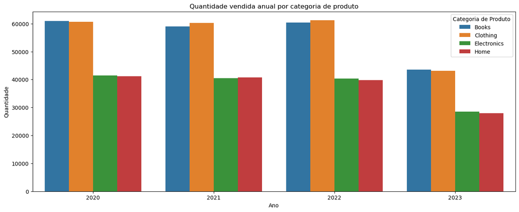

```python
# desenha gráfico de barras Categoria de Produto x Quantidade por ano
graphic.figure(figsize=(16, 6))
barra = seaborn.barplot(x=ANO_COMPRA, y=QUANTIDADE, hue=CATEGORIA_PRODUTO, data=total_por_produto_x_ano)
barra.legend(title='Categoria de Produto')
graphic.xlabel('Ano')
graphic.ylabel('Quantidade')
graphic.title('Quantidade vendida anual por categoria de produto')
graphic.show()
```

## 4 - Qual o produto com melhor e pior NPS?

### Resposta:

Analisando somente pelas colunas de produto e nps iremos notar que:

- o melhor NPS está na categoria de produto Home
- o pior NPS está na categoria de produto Electronics

Já se fizermos a análise com o ano teremos alterações, por exemplo:

- 2023:
  - melhor NPS: Clothing
  - pior NPS: Electronics
- 2021:
  - melhor NPS: Books
  - pior NPS: Clothing

```python
# calcula a média do nps por produto
media_nps_por_produto = dados.groupby(CATEGORIA_PRODUTO).nps.mean().reset_index()
media_nps_por_produto_ordenado = media_nps_por_produto.sort_values(by=[NPS], ascending=False)
display(media_nps_por_produto_ordenado)
```

|  | categoria_produto | nps |
| --- | --- | --- |
| 3 | Home | 5.011394 |
| 0 | Books | 5.003698 |
| 1 | Clothing | 4.983904 |
| 2 | Electronics | 4.966544 |

```python
# calcula a média do nps por produto x ano
media_nps_por_produto_x_ano = dados.groupby([CATEGORIA_PRODUTO, ANO_COMPRA]).nps.mean().reset_index()
tabela = pd.pivot_table(media_nps_por_produto_x_ano, values=[NPS], index=[ANO_COMPRA], columns=[CATEGORIA_PRODUTO], fill_value=0)
display(tabela)
```

| categoria_produto ano_compra | nps Books | nps Clothing | nps Electronics | nps Home |
| --- | --- | --- | --- | --- |
| 2020 | 5.002841 | 4.988171 | 4.944977 | 5.026928 |
| 2021 | 5.018470 | 4.962722 | 5.003393 | 5.018148 |
| 2022 | 4.983725 | 4.976742 | 4.954095 | 5.013663 |
| 2023 | 5.012293 | 5.017650 | 4.962759 | 4.975758 |

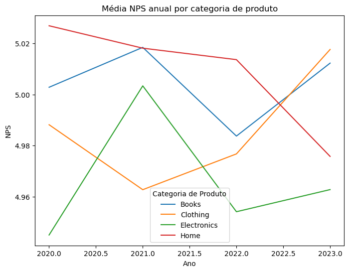

```python
# desenha gráfico de linhas Categoria de Produto x NPS por ano
graphic.figure(figsize=(8, 6))
linha = seaborn.lineplot(x=ANO_COMPRA, y=NPS, hue=CATEGORIA_PRODUTO, data=media_nps_por_produto_x_ano)
linha.legend(title='Categoria de Produto')
graphic.xlabel('Ano')
graphic.ylabel('NPS')
graphic.title('Média NPS anual por categoria de produto')
graphic.show()
```